# Vodka & R

September 27, 2016

## Hvad er R og hvad skal vi lære?

## R og RStudio

- [R](https://cran.r-project.org/bin/windows/base/) er et programmeringssprog
- [RStudio](https://www.rstudio.com/) er et *integrated development enviroment* … Det er programmet der håndterer R kode
- [Rmarkdown](http://rmarkdown.rstudio.com/) er RStudios integrerede markup-pakke
- Det meste funtionalitet er drevet af 3.partsudviklere, deres arbejde findes på [CRAN](https://cran.r-project.org/) og udviklingsplatformen github
- Går man i stå kan [stackoverflow](http://stackoverflow.com/) altid svaret.

## RStudio

[figure not shown]

## RStudio kan (næsten) alt

- Dataindsamling fra nettet
  - og et hav af dataformater
- Datamanipulering
- Statistisk analyse
  - Både almindelige regressioner, og myriader af mere moderne metoder
- Visualisering
- Publicering
  - med LaTeX, slideshows, HTML, Word, Shinyapps m.fl.

## Rmarkdown

- Markdown er en *plain text formatting syntax* - dvs markdown laver et .txt dokument om til et formatteret dokument.
- Rmarkdown er markdown + pandoc + R
  - *pandoc* er, som navnet antyder, et program der omformatterer fra et dokumentformat til et andet. Derfor kan Rmarkdown læse bl.a. LaTeX og HTML
  - Rmarkdown kan køre R kode
- Rmarkdown er smart fordi det er 100% reproducerbart - når ens bachelorvejleder spørger hvordan man er nået frem til sine figurer sender man bare råfilen, med en henvisning til det relevante stykke kode.
- For eksempel er dette slideshow lavet i Rmarkdown.

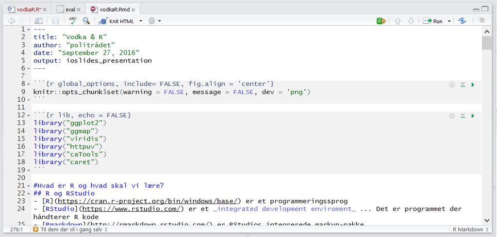

## Lad os lave noget konkret - folketingsvalg i Danmark

- dataindsamling
- manipulering
- Statistiske metoder
- Visualisering

## Data

## Data - hvorfra?

Vi henter data fra DST og et kort over Danmark fra [Sebastians](http://sebastianbarfort.github.io/) hjemmelavede (og ubrugelige) pakke *mapDK*

```r
load("municipality.rda")

df_raw = read.csv("dkelec.csv", header = FALSE, sep =";")
df = df_raw
colnames(df) = c("party", "location", "res_2007","res_2011","res_2015")
```

[output not shown]

Der er masser af pakker til at loade data, fx `readr` og `rio`. `rvest` er bygget til at scrape data fra nettet.

## Data - manipulationer

Foregår med R's indbyggede funktioner, og pakkerne `tidyr` og `dplyr`

- Først lidt fodarbejde

```r
df$party = as.character(df$party)
```

- Så korrektioner for sprogforvirring (tak DST)

```r
df$location = gsub("æ", "ae", df$location)
```

- …og lidt flere justeringer

Når datasættet er i orden kan vi lave intressante mål, for eksempel stemmeandele

```r
df$pct_15 = df$res_2015 / df$total_15 * 100
```

## Målet: tidy data

- Tidy data er den "*korrekte*" måde at opstille data
  - Målet er at have variable i kolonner og observationer i rækker

## Visualiseringer

## ggplot2

ggplot kan visualisere næsten alt, og er bygget omkring et intuitivt system: *grammar of graphics*.

1. Definer `ggplot`'s grundelement, indtil videre er det kun en x- og en y-akse.

```r
p = ggplot(data = df)
```

1. Tilføj variable med *aesthetics*, for eksempel punkter.

```r
p = p + geom_point(aes(x = xvar, y = yvar, color = zvar), size = 2)
```

1. Eventuelle visuelle detaljer kommer til sidst

```r
p = p + scale_color_viridis()
      + ggtitle("TITEL")
```

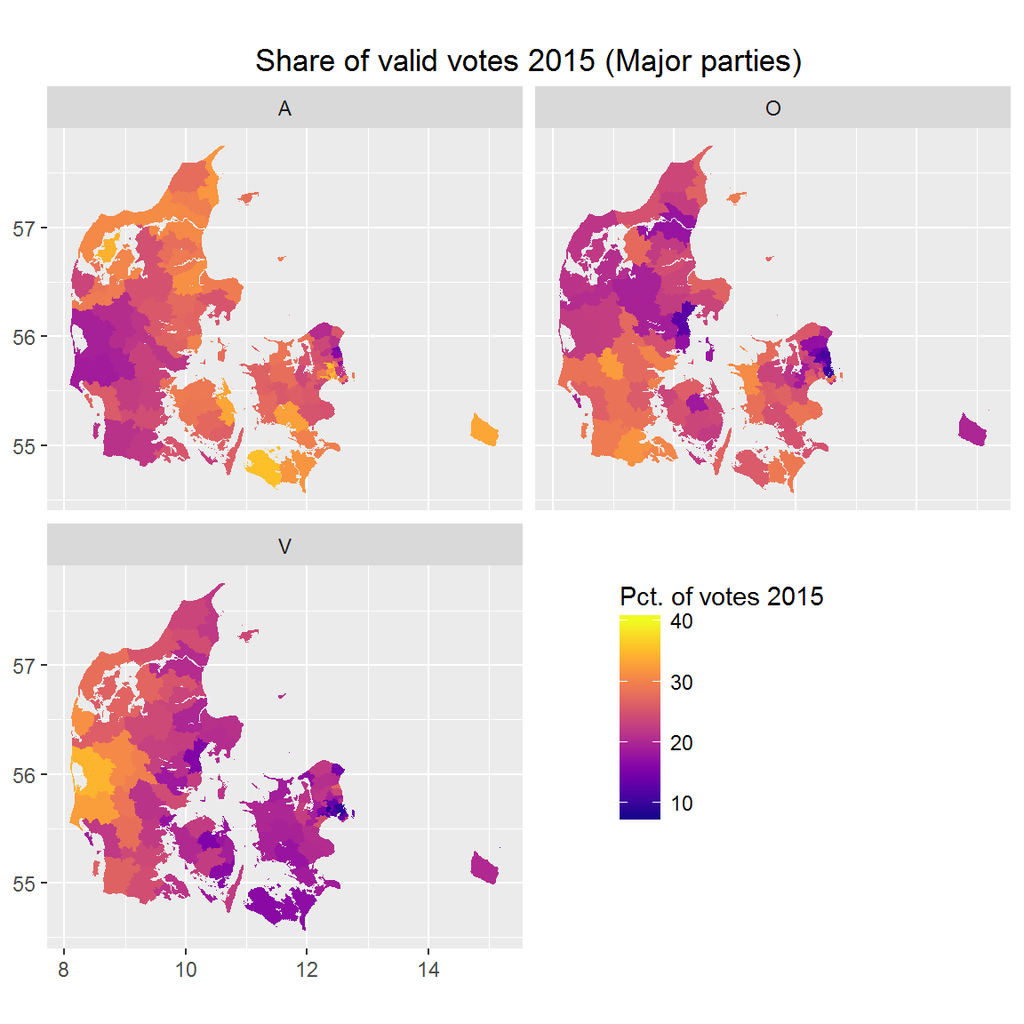

## Frem- og tilbagegang

[interactive chart not shown]

## Statistik

## k-NN

På forrige slide, er det tydeligt at partierne er clustered \(\Rightarrow\) Måske kan vi forudsige partiets bogstav ud fra stemmeandelen i 2007 og 2015?

kNN er en af de simpleste kategoriseringsalgoritmer man kan forestille sig:

- udregn den euklidiske afstand i n dimensioner (Pythagoras):

\[ \begin{align*} d(x_i, x_j) = \sqrt{ \sum_{k=1}^n (x_{ik} - x_{jk})^2 } \end{align*} \]

- Opdel datasættet i *test* og *train*
- Klassificer punkterne i *test* ud fra deres k nærmeste naboer i *train*

## k-NN - resultater

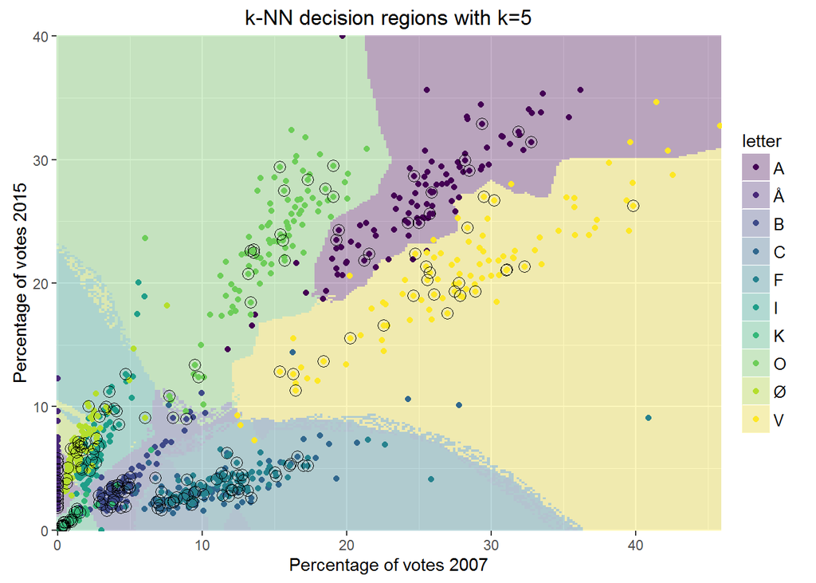

## Så hvor godt er det?

- k-NN rammer rigtigt på 78.5% af *test* sættet, der er 10 kategorier, så tilfældige gæt svarer til en succesrate på 10% - Men hvad med andre algoritmer?
- Nogle klassificeringsalgoritmer kan gøre det bedre, andre kan ikke.
- De fleste er mindre intuitive end k-NN
  - `caret` har over 230 klassifikations og regressionsmodeller indbygget.
  - Hvilken algoritme der virker, afhænger af data - for eksempel er Neural Networks meget bedre til at fange vores data's stråle-struktur

## Hvad har vi lært?

## Til dem der vil i gang selv

Lær ting i samme rækkefølge som de er gennemgået i dette slideshow, og brug Sebastians materiale.

Slides fra [Social Data Science](http://sebastianbarfort.github.io/sds_summer/syllabus/)  
Obligatorisk [100 siders introduktion](https://cran.r-project.org/doc/manuals/R-intro.pdf) til R  
[Cookbook for R](http://www.cookbook-r.com/)  
data + kode til [mine slides](https://github.com/Kristianuruplarsen/vodkaR_presentation)